# hw2

```
## [1] 4746 1418
```

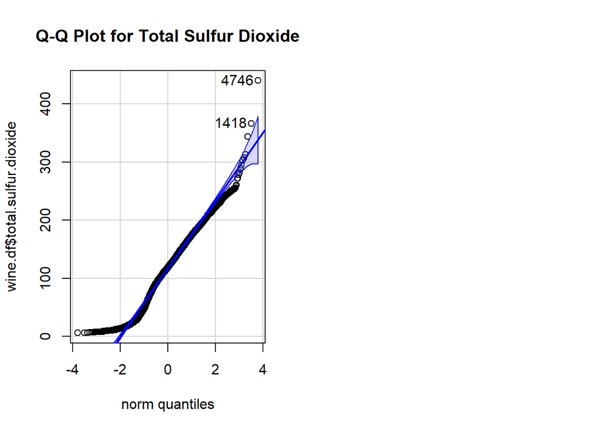

```r
qqPlot(wine.df$`total.sulfur.dioxide`, main = "Q-Q Plot for Total Sulfur Dioxide")
```

```r
if (all(wine.df$`total.sulfur.dioxide` > 0)) {
  wine.df$`total.sulfur.dioxide` <- log(wine.df$`total.sulfur.dioxide`)
} else {
  stop("Log transformation requires all values to be positive.")
}
mu_transformed <- mean(wine.df$`total.sulfur.dioxide`, na.rm = TRUE)
sigma_transformed <- sd(wine.df$`total.sulfur.dioxide`, na.rm = TRUE)
cat(sprintf("Transformed mu total sulfur dioxide: %f, sigma total sulfur dioxide: %f\n", mu_transformed, sigma_transformed))
```

```
## Transformed mu total sulfur dioxide: 4.563833, sigma total sulfur dioxide: 0.714447
```

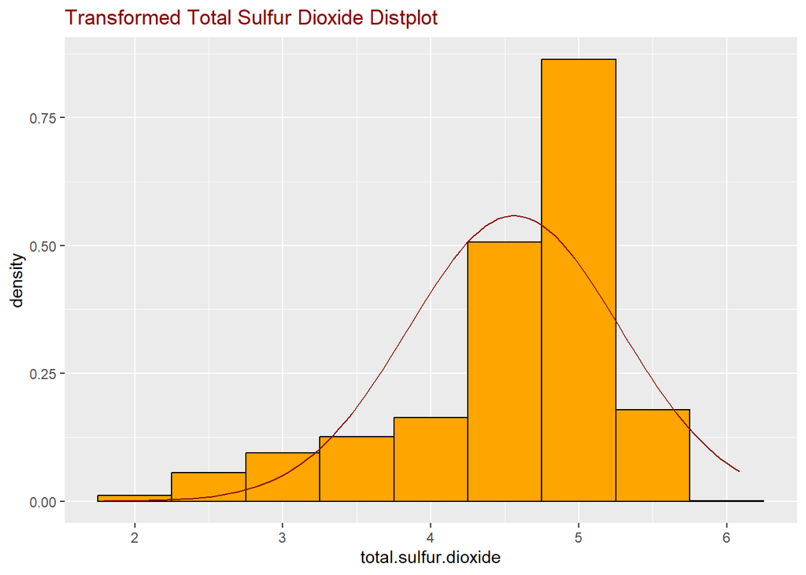

```r
par(mfrow = c(1, 2))
ggplot(wine.df, aes(x = `total.sulfur.dioxide`)) +
  geom_histogram(aes(y = ..density..), binwidth = 0.5, fill = "orange", color = "black") +
  stat_function(fun = dnorm, args = list(mean = mu_transformed, sd = sigma_transformed), color = "darkred") +
  ggtitle("Transformed Total Sulfur Dioxide Distplot") +
  theme(plot.title = element_text(color = "darkred"))
```

```
## [1] 5814 5878
```

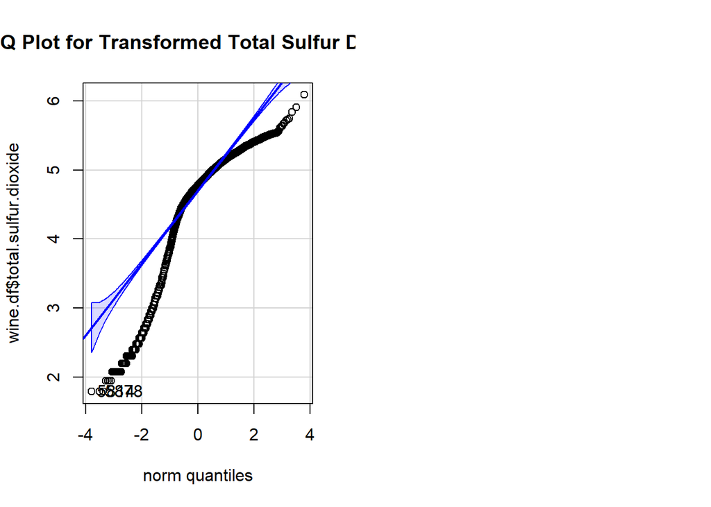

```r
qqPlot(wine.df$`total.sulfur.dioxide`, main = "Q-Q Plot for Transformed Total Sulfur Dioxide")
```

```r
### alcohol
mu <- mean(wine.df$`alcohol`, na.rm = TRUE)
sigma <- sd(wine.df$`alcohol`, na.rm = TRUE)
cat(sprintf("mu alcohol: %f, sigmaalcohol: %f\n", mu, sigma))
```

```
## mu alcohol: 10.491801, sigmaalcohol: 1.192712
```

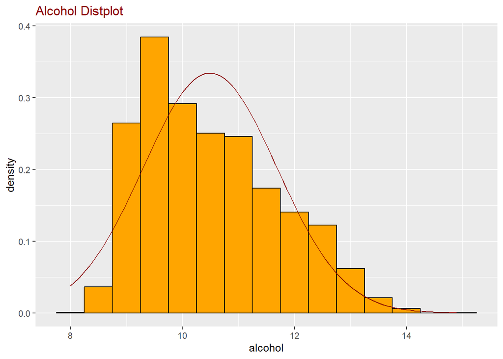

```r
par(mfrow = c(1, 2))
ggplot(wine.df, aes(x = `alcohol`)) +
  geom_histogram(aes(y = ..density..), binwidth = 0.5, fill = "orange", color = "black") +
  stat_function(fun = dnorm, args = list(mean = mu, sd = sigma), color = "darkred") +
  ggtitle("Alcohol Distplot") +
  theme(plot.title = element_text(color = "darkred"))
```

```
## [1] 5551 3919
```

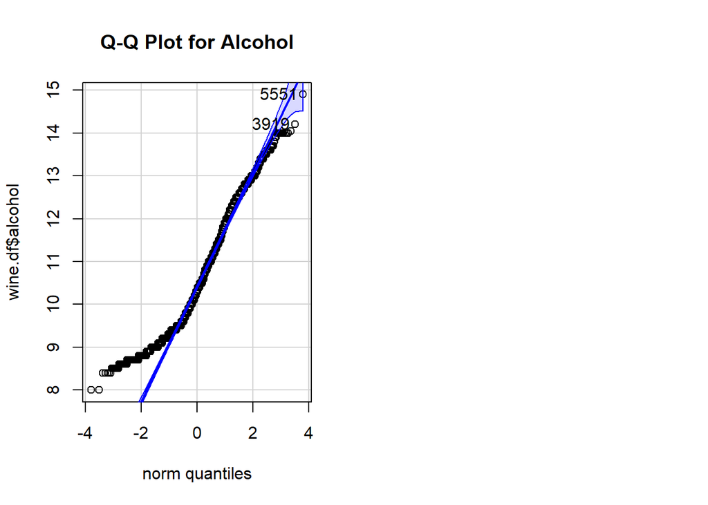

```r
qqPlot(wine.df$`alcohol`, main = "Q-Q Plot for Alcohol")
```

```r
if (all(wine.df$`alcohol` > 0)) {
  wine.df$`alcohol` <- log(wine.df$`alcohol`)
} else {
  stop("Log transformation requires all values to be positive.")
}
mu_transformed <- mean(wine.df$`alcohol`, na.rm = TRUE)
sigma_transformed <- sd(wine.df$`alcohol`, na.rm = TRUE)
cat(sprintf("Transformed mu alcohol: %f, sigma alcohol: %f\n", mu_transformed, sigma_transformed))
```

```
## Transformed mu alcohol: 2.344317, sigma alcohol: 0.111313
```

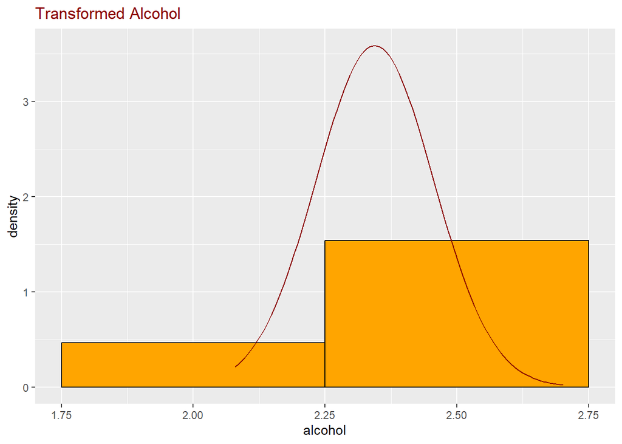

```r
par(mfrow = c(1, 2))
ggplot(wine.df, aes(x = `alcohol`)) +
  geom_histogram(aes(y = ..density..), binwidth = 0.5, fill = "orange", color = "black") +
  stat_function(fun = dnorm, args = list(mean = mu_transformed, sd = sigma_transformed), color = "darkred") +
  ggtitle("Transformed Alcohol") +
  theme(plot.title = element_text(color = "darkred"))
```

```
## [1] 5551 3919
```

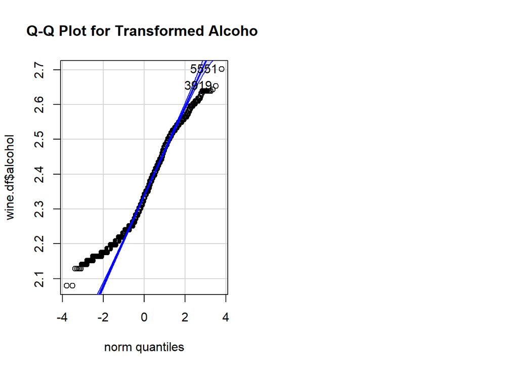

```r
qqPlot(wine.df$`alcohol`, main = "Q-Q Plot for Transformed Alcohol")
```

### Outlier Detection

```r
detect_outliers_class_specific <- function(df, features, class_col) {
  outlier_indices <- list()

  unique_classes <- unique(df[[class_col]])
  for (class in unique_classes) {
    class_df <- df[df[[class_col]] == class, ]
    class_outliers <- numeric()

    if (nrow(class_df) > 0) {
      for (c in features) {
        Q1 <- quantile(class_df[[c]], 0.25, na.rm = TRUE)
        Q3 <- quantile(class_df[[c]], 0.75, na.rm = TRUE)
        IQR <- Q3 - Q1
        outlier_step <- IQR * 1.5

        # Detect outliers within class
        outliers <- which(class_df[[c]] < Q1 - outlier_step | class_df[[c]] > Q3 + outlier_step)
        class_outliers <- c(class_outliers, outliers)
      }
    }

    outlier_indices[[as.character(class)]] <- unique(class_outliers) + min(which(df[[class_col]] == class)) - 1
  }

  return(outlier_indices)
}

features <- colnames(wine.df)[1:(ncol(wine.df) - 1)]
class_col <- "quality"
outlier_rows <- detect_outliers_class_specific(wine.df, features, class_col)

for (class in names(outlier_rows)) {
  num_outliers <- length(outlier_rows[[class]])
  cat(paste("Quality", class, "has", num_outliers, "outliers.\n"))
}
```

```
## Quality 6 has 682 outliers.
## Quality 5 has 402 outliers.
## Quality 7 has 225 outliers.
## Quality 8 has 64 outliers.
## Quality 4 has 28 outliers.
## Quality 3 has 6 outliers.
## Quality 9 has 3 outliers.
```

```r
features <- colnames(wine.df)[1:(ncol(wine.df) - 1)]
class_col <- "quality"
outlier_rows <- detect_outliers_class_specific(wine.df, features, class_col)

for (class in unique(wine.df[[class_col]])) {
  class_as_character <- as.character(class)
  total_in_class <- sum(wine.df[[class_col]] == class)
  if (is.null(outlier_rows[[class_as_character]])) {
    cat(paste("Quality", class_as_character, "has 0 outliers out of", total_in_class, "data, 0%.\n"))
  } else {
    num_outliers <- length(outlier_rows[[class_as_character]])
    percentage_outliers <- round((num_outliers / total_in_class) * 100, 2)
    cat(paste("Quality", class_as_character, "has", num_outliers, "outliers out of", total_in_class, "data,", percentage_outliers, "%.\n"))
  }
}
```

```
## Quality 6 has 682 outliers out of 2836 data, 24.05 %.
## Quality 5 has 402 outliers out of 2138 data, 18.8 %.
## Quality 7 has 225 outliers out of 1079 data, 20.85 %.
## Quality 8 has 64 outliers out of 193 data, 33.16 %.
## Quality 4 has 28 outliers out of 216 data, 12.96 %.
## Quality 3 has 6 outliers out of 30 data, 20 %.
## Quality 9 has 3 outliers out of 5 data, 60 %.
```

### Balancing Data

Our data has severe class imbalanc, especially the minority class is very small (like Quality 9 class), therefore we decided that resampling might be more effective.

Due to some R techinical issues on both of our laptops, we couldn’t use SMOTE, We considered a combination approach to avoid having too few instances of the majority classes after balancing. We use a mix of oversampling the minority classes and undersampling the majority classes to achieve a reasonable balance that doesn’t overly disadvantage either group.

```r
set.seed(123)

target_size_minority <- 500

target_size_majority <- 1000

oversample_class <- function(df, class, target_size) {
  class_data <- df[df$quality == class, ]
  oversampled_class_data <- class_data[sample(1:nrow(class_data), target_size, replace = TRUE), ]
  return(oversampled_class_data)
}

# Oversample minority classes
minority_classes <- c(3, 4, 8, 9)
oversampled_classes <- lapply(minority_classes, function(class) oversample_class(wine.df, class, target_size_minority))

# Undersample majority classes
majority_classes <- c(5, 6, 7)
undersampled_classes <- lapply(majority_classes, function(class) oversample_class(wine.df, class, target_size_majority))

# Combine the balanced classes with the rest of the data
balanced_data <- rbind(
  do.call(rbind, oversampled_classes),
  do.call(rbind, undersampled_classes),
  wine.df[!wine.df$quality %in% c(minority_classes, majority_classes), ]
)

# Check the new distribution
table(balanced_data$quality)
```

```
##
##    3    4    5    6    7    8    9
##  500  500 1000 1000 1000  500  500
```

### Modeling

Sine we have a lot of outliers in our data we thought using models that are robust to outliers is wise. First we will see the result of Naive Bayes which is a statistical learning method, and we will use Random Forest as machine learning models.

```r
#install.packages(c("e1071", "randomForest", "gbm"))

library(e1071)
library(randomForest)
library(gbm)
```

We have a dataset where ‘quality’ is our target variable, and it comprises several classes. Other variables in the dataset are predictors or features.

```r
set.seed(123)
balanced_data <- subset(balanced_data, select = -type)
train_indices <- sample(1:nrow(balanced_data), size = 0.7 * nrow(balanced_data))
train_data <- balanced_data[train_indices, ]
test_data <- balanced_data[-train_indices, ]
```

### Naive Bayes Model

Cross-validation, especially in a dataset like ours where certain quality classes might be underrepresented, helps in obtaining a more reliable estimate of model performance. It mitigates the risk of overfitting and provides a better understanding of how the model might perform on unseen data. So first, we will look up on pure Navie Bayes model’s accuracy and then implement cross validation.

```r
nb_model <- naiveBayes(quality ~ ., data = train_data)
nb_pred <- predict(nb_model, test_data[-ncol(test_data)])
nb_accuracy <- sum(nb_pred == test_data$quality) / nrow(test_data)
print(paste("Naive Bayes accuracy:", nb_accuracy))
```

```
## [1] "Naive Bayes accuracy: 0.374666666666667"
```

```r
library(caret)
train_data$quality <- as.factor(train_data$quality)
control <- trainControl(method = "cv", number = 10)
cv_naive_bayes_model <- train(quality ~ ., data = train_data, method = "naive_bayes", trControl = control)
print(cv_naive_bayes_model)
```

```
## Naive Bayes
##
## 3500 samples
##   11 predictor
##    7 classes: '3', '4', '5', '6', '7', '8', '9'
##
## No pre-processing
## Resampling: Cross-Validated (10 fold)
## Summary of sample sizes: 3149, 3151, 3150, 3150, 3150, 3152, ...
## Resampling results across tuning parameters:
##
##   usekernel  Accuracy   Kappa
##   FALSE      0.3608435  0.2433084
##    TRUE      0.4842765  0.3830140
##
## Tuning parameter 'laplace' was held constant at a value of 0
## Tuning
##  parameter 'adjust' was held constant at a value of 1
## Accuracy was used to select the optimal model using the largest value.
## The final values used for the model were laplace = 0, usekernel = TRUE
##  and adjust = 1.
```

### Random Forest

Thinking of the chracteristic of our data which has a lot of out liers and class, we used Random Forest with cross validation. Furthermore We converted the ‘quality’ variable into a factor with defined levels. This step is crucial for categorical data in classification problems.

Random Forest, an ensemble learning method, uses multiple decision trees to make better predictions than a single tree. So we use 500 trees with the expecation of enhancing model accuracy and generalization.

```r
train_data <- as.data.frame(train_data)
test_data <- as.data.frame(test_data)

unique_quality_levels <- sort(unique(balanced_data$quality))
train_data$quality <- factor(train_data$quality, levels = unique_quality_levels)
test_data$quality <- factor(test_data$quality, levels = unique_quality_levels)


rf_model <- randomForest(quality ~ ., data = train_data, ntree = 500)
rf_pred <- predict(rf_model, test_data)
rf_pred <- factor(rf_pred, levels = unique_quality_levels)


conf_matrix <- confusionMatrix(rf_pred, test_data$quality)
print(conf_matrix)
```

```
## Confusion Matrix and Statistics
##
##           Reference
## Prediction   3   4   5   6   7   8   9
##          3 150   0   0   0   0   0   0
##          4   0 136  11   3   0   0   0
##          5   0  16 255  65   6   3   0
##          6   0   5  32 164  25   1   0
##          7   0   1   8  60 250  15   0
##          8   0   0   0   2   9 130   0
##          9   0   0   0   0   0   0 153
##
## Overall Statistics
##
##                Accuracy : 0.8253
##                  95% CI : (0.8052, 0.8442)
##     No Information Rate : 0.204
##     P-Value [Acc > NIR] : < 2.2e-16
##
##                   Kappa : 0.7921
##
##  Mcnemar's Test P-Value : NA
##
## Statistics by Class:
##
##                      Class: 3 Class: 4 Class: 5 Class: 6 Class: 7 Class: 8
## Sensitivity               1.0  0.86076   0.8333   0.5578   0.8621  0.87248
## Specificity               1.0  0.98957   0.9246   0.9478   0.9306  0.99186
## Pos Pred Value            1.0  0.90667   0.7391   0.7225   0.7485  0.92199
## Neg Pred Value            1.0  0.98370   0.9558   0.8979   0.9657  0.98602
## Prevalence                0.1  0.10533   0.2040   0.1960   0.1933  0.09933
## Detection Rate            0.1  0.09067   0.1700   0.1093   0.1667  0.08667
## Detection Prevalence      0.1  0.10000   0.2300   0.1513   0.2227  0.09400
## Balanced Accuracy         1.0  0.92516   0.8790   0.7528   0.8963  0.93217
##                      Class: 9
## Sensitivity             1.000
## Specificity             1.000
## Pos Pred Value          1.000
## Neg Pred Value          1.000
## Prevalence              0.102
## Detection Rate          0.102
## Detection Prevalence    0.102
## Balanced Accuracy       1.000
```

```r
fitControl <- trainControl(method = "cv", number = 5)  # 5-fold cross-validation
cv_rf_model <- train(quality ~ ., data = train_data, method = "rf", trControl = fitControl, tuneLength = 5)
print(cv_rf_model)
```

```
## Random Forest
##
## 3500 samples
##   11 predictor
##    7 classes: '3', '4', '5', '6', '7', '8', '9'
##
## No pre-processing
## Resampling: Cross-Validated (5 fold)
## Summary of sample sizes: 2801, 2797, 2799, 2801, 2802
## Resampling results across tuning parameters:
##
##   mtry  Accuracy   Kappa
##    2    0.7819729  0.7398188
##    4    0.7776876  0.7349056
##    6    0.7773945  0.7346774
##    8    0.7736835  0.7303055
##   11    0.7711247  0.7273523
##
## Accuracy was used to select the optimal model using the largest value.
## The final value used for the model was mtry = 2.
```

# Regression

Now for the part of regression we are going to try to find the elements that mostly influence the quality of the wine. We are going to use several regression models to decide which one of them gives us the best result and to get a conclusion about how the rest of the variables affect the quality of the wine.

import all the libraries:

```r
library(leaflet)
library(tidyverse)
library(MASS)
library(caret)
library(MASS)
library(olsrr)
```

The first step is always to split the data. We decided to split it 75% train and 25% test. Also, we transpormed the variable type into a binary variable to use it in our models.

```r
wine.df$type <- ifelse(wine.df$type == "red", 1, 0)
in_train <-
  createDataPartition(wine.df$alcohol, p = 0.75, list = FALSE)
training <- wine.df[in_train, ]
testing <- wine.df[-in_train, ]
nrow(training)
```

```
## [1] 4874
```

```r
nrow(testing)
```

```
## [1] 1623
```

Then, we start by doing a simple linear regression and plotting it. As the alcohol and quality are very positively correlated, we are going to use those variables first.

```r
qualityFit <- lm(quality ~ alcohol, data = training)
predictedQuality <- predict(qualityFit, newdata=testing)
predictedQualityRounded <- round(predictedQuality)
correlationQuality <- cor(testing$quality, predictedQualityRounded)
rSquaredQuality <- correlationQuality^2
cat("Correlation:", correlationQuality, "\n")
```

```
## Correlation: 0.3284289
```

```r
cat("R-squared:", rSquaredQuality, "\n")
```

```
## R-squared: 0.1078655
```

we get a positive correlation between the two of them.

Now we check the relation between density and alcohol

```r
linFit <- lm(density ~ alcohol, data = training)
predictedDensity <- predict(linFit, newdata=testing)

correlationDensity <- cor(testing$density, predictedDensity)
rSquaredDensity <- correlationDensity^2


cat("Correlation:", correlationDensity, "\n")
```

```
## Correlation: 0.7049358
```

```r
cat("R-squared:", rSquaredDensity, "\n")
```

```
## R-squared: 0.4969344
```

### Multiple regression:

```r
linFit <- lm(quality ~ alcohol + volatile.acidity + chlorides + free.sulfur.dioxide + total.sulfur.dioxide + density + pH + sulphates, data = training)
summary(linFit)
```

```
##
## Call:
## lm(formula = quality ~ alcohol + volatile.acidity + chlorides +
##     free.sulfur.dioxide + total.sulfur.dioxide + density + pH +
##     sulphates, data = training)
##
## Residuals:
##     Min      1Q  Median      3Q     Max
## -3.3514 -0.4646 -0.0406  0.4797  3.0794
##
## Coefficients:
##                       Estimate Std. Error t value Pr(>|t|)
## (Intercept)          -24.65751    5.64724  -4.366 1.29e-05 ***
## alcohol                3.57912    0.14648  24.434  < 2e-16 ***
## volatile.acidity      -1.42391    0.07885 -18.059  < 2e-16 ***
## chlorides             -1.08744    0.36420  -2.986  0.00284 **
## free.sulfur.dioxide    0.28644    0.02459  11.649  < 2e-16 ***
## total.sulfur.dioxide  -0.23070    0.02690  -8.577  < 2e-16 ***
## density               22.52450    5.42948   4.149 3.40e-05 ***
## pH                     0.02689    0.07097   0.379  0.70481
## sulphates              0.50782    0.08367   6.069 1.38e-09 ***
## ---
## Signif. codes:  0 '***' 0.001 '**' 0.01 '*' 0.05 '.' 0.1 ' ' 1
##
## Residual standard error: 0.7459 on 4865 degrees of freedom
## Multiple R-squared:  0.277,  Adjusted R-squared:  0.2758
## F-statistic:   233 on 8 and 4865 DF,  p-value: < 2.2e-16
```

From this we got that this is not the best model as there is only about 30% of the variances informed, this could mean that we should include some other variables here. Also, we obtained that ph has no significant relation to the quality. On the other hand, this model suggest that the higher the alcohol the better and the less volatile.acidity the better. Also, the density seems to be very significant to the result.

```r
pr.multiple = predict(linFit, newdata=testing)
cor(testing$quality, pr.multiple)^2
```

```
## [1] 0.3407269
```

```r
print(dim(testing))
```

```
## [1] 1623   13
```

Again, we are in the same point as before the model works but there is room for improvement.

After this first approach lets analyse, which variables are the most significant for the variable quality. As density has a great influence in the variable quality, we try to find the best model for it.

```r
linFitQuality <- lm(density ~ fixed.acidity + volatile.acidity + citric.acid + residual.sugar + chlorides + free.sulfur.dioxide + total.sulfur.dioxide + alcohol + pH + sulphates + quality + type, data = training)


ols_step_best_subset(linFitQuality)
```

```
##                                                                    Best Subsets Regression
## -------------------------------------------------------------------------------------------------------------------------------------------------------------
## Model Index    Predictors
## -------------------------------------------------------------------------------------------------------------------------------------------------------------
##      1         alcohol
##      2         fixed.acidity alcohol
##      3         residual.sugar alcohol type
##      4         fixed.acidity residual.sugar alcohol type
##      5         fixed.acidity residual.sugar alcohol pH type
##      6         fixed.acidity residual.sugar alcohol pH sulphates type
##      7         fixed.acidity citric.acid residual.sugar alcohol pH sulphates type
##      8         fixed.acidity volatile.acidity citric.acid residual.sugar alcohol pH sulphates type
##      9         fixed.acidity volatile.acidity citric.acid residual.sugar alcohol pH sulphates quality type
##     10         fixed.acidity volatile.acidity citric.acid residual.sugar free.sulfur.dioxide alcohol pH sulphates quality type
##     11         fixed.acidity volatile.acidity citric.acid residual.sugar free.sulfur.dioxide total.sulfur.dioxide alcohol pH sulphates quality type
##     12         fixed.acidity volatile.acidity citric.acid residual.sugar chlorides free.sulfur.dioxide total.sulfur.dioxide alcohol pH sulphates quality type
## -------------------------------------------------------------------------------------------------------------------------------------------------------------
##
##                                                          Subsets Regression Summary
## --------------------------------------------------------------------------------------------------------------------------------------------
##                        Adj.        Pred
## Model    R-Square    R-Square    R-Square       C(p)           AIC           SBIC            SBC         MSEP      FPE       HSP       APC
## --------------------------------------------------------------------------------------------------------------------------------------------
##   1        0.4674      0.4673       0.467    21013.7124    -45747.4912    -59583.8685    -45728.0162    0.0239    0.0000    0.0000    0.5330
##   2        0.6191      0.6189      0.6186    13644.9904    -47378.9696    -61216.2883    -47353.0029    0.0171    0.0000    0.0000    0.3814
##   3        0.8181      0.8180      0.8176     3973.3809    -50980.1025    -64815.9066    -50947.6441    0.0082    0.0000    0.0000    0.1822
##   4        0.8649      0.8648      0.8644     1702.9934    -52426.4639    -66260.9877    -52387.5139    0.0061    0.0000    0.0000    0.1354
##   5        0.8928      0.8926      0.8922      349.8752    -53550.9252    -67383.5244    -53505.4835    0.0048    0.0000    0.0000    0.1075
##   6        0.8974      0.8973      0.8968      126.4235    -53764.4574    -67596.5868    -53712.5240    0.0046    0.0000    0.0000    0.1029
##   7        0.8982      0.8981      0.8976       87.0805    -53803.0367    -67635.0799    -53744.6117    0.0046    0.0000    0.0000    0.1021
##   8        0.8991      0.8989      0.8978       49.1938    -53840.5095    -67672.4368    -53775.5928    0.0045    0.0000    0.0000    0.1013
##   9        0.8995      0.8994      0.8982       27.8010    -53861.8091    -67693.6539    -53790.4008    0.0045    0.0000    0.0000    0.1009
##  10        0.8998      0.8996      0.8984       15.9147    -53873.6930    -67705.4783    -53795.7929    0.0045    0.0000    0.0000    0.1006
##  11        0.8999      0.8997      0.8984       12.3012    -53877.3167    -67709.0718    -53792.9250    0.0045    0.0000    0.0000    0.1005
##  12        0.9000      0.8997      0.8984       13.0000    -53876.6212    -67708.3645    -53785.7378    0.0045    0.0000    0.0000    0.1006
## --------------------------------------------------------------------------------------------------------------------------------------------
## AIC: Akaike Information Criteria
##  SBIC: Sawa's Bayesian Information Criteria
##  SBC: Schwarz Bayesian Criteria
##  MSEP: Estimated error of prediction, assuming multivariate normality
##  FPE: Final Prediction Error
##  HSP: Hocking's Sp
##  APC: Amemiya Prediction Criteria
```

```r
names(training)
```

```
##  [1] "fixed.acidity"        "volatile.acidity"     "citric.acid"
##  [4] "residual.sugar"       "chlorides"            "free.sulfur.dioxide"
##  [7] "total.sulfur.dioxide" "density"              "pH"
## [10] "sulphates"            "alcohol"              "quality"
## [13] "type"
```

Therefore, from this table we got that the best models would be 10, 11 or 12 due to it’s values. we see that R^2 is relatively high, and the AIC and BIC are the lowest.

```r
model = density ~ fixed.acidity + volatile.acidity + citric.acid + residual.sugar +
  free.sulfur.dioxide + alcohol + pH + sulphates + quality + type
benchFitQuality <- lm(density ~ ., data = training)

predictionsQuality <- predict(benchFitQuality, newdata = testing)

corQualitySquared <- cor(testing$density, predictionsQuality) ^ 2
corQualitySquared
```

```
## [1] 0.9335467
```

```r
RMSEQuality <- sqrt(mean((predictionsQuality - testing$density) ^ 2))
RMSEQuality
```

```
## [1] 0.0007456161
```

we obtained that the model does very good for the density as the r^2 is very high and the RME is very low. We have to be careful because there is a chance of overfitting so we create a cross validation control for out future models.

```r
ctrl <- trainControl(method = "repeatedcv",
                     number = 10, repeats = 1)

test_results <- data.frame(density = testing$density)
```

### Linear regression

```r
lm_tune <- train(model, data = training,
                 method = "lm",
                 preProc=c('scale', 'center'),
                 trControl = ctrl)
lm_tune
```

```
## Linear Regression
##
## 4874 samples
##   10 predictor
##
## Pre-processing: scaled (10), centered (10)
## Resampling: Cross-Validated (10 fold, repeated 1 times)
## Summary of sample sizes: 4386, 4388, 4387, 4387, 4387, 4387, ...
## Resampling results:
##
##   RMSE          Rsquared  MAE
##   0.0009041505  0.906716  0.0006004687
##
## Tuning parameter 'intercept' was held constant at a value of TRUE
```

```r
test_results$lm <- predict(lm_tune, testing)
postResample(pred = test_results$lm,  obs = test_results$density)
```

```
##         RMSE     Rsquared          MAE
## 0.0007463979 0.9334326602 0.0005988287
```

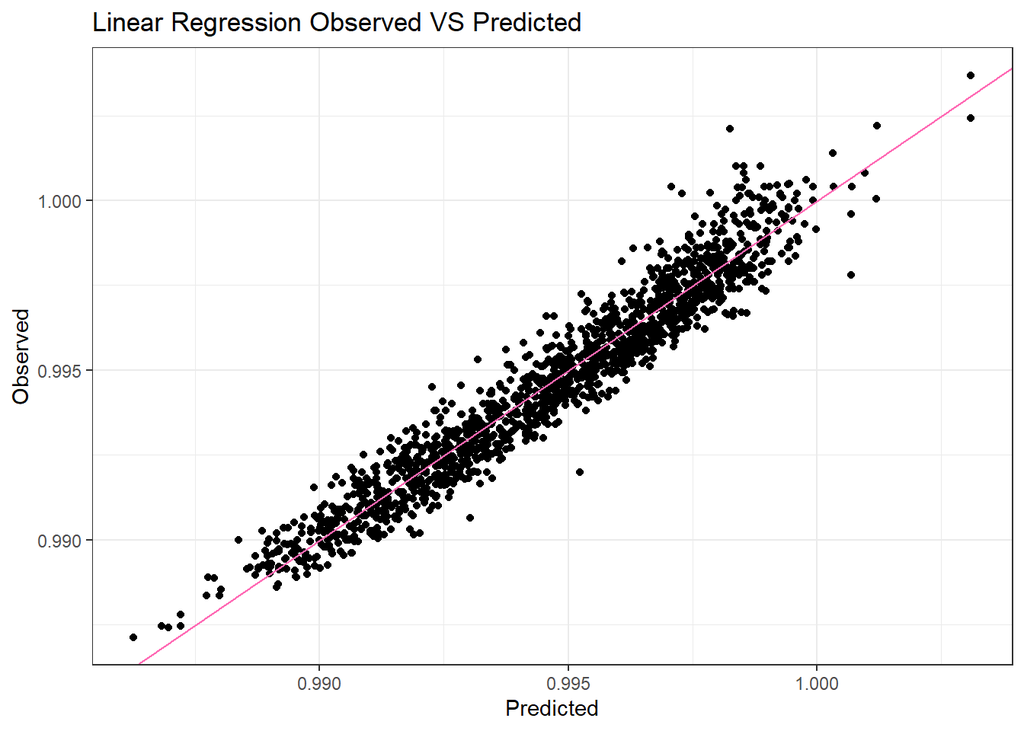

```r
qplot(test_results$lm, test_results$density) +
  labs(title = "Linear Regression Observed VS Predicted", x = "Predicted", y = "Observed") + geom_abline(intercept = 0, slope = 1, colour = "hotpink") + theme_bw()
```

```r
missing_rows <- which(!complete.cases(test_results$lm, test_results$density))

print(test_results[missing_rows, c("lm", "density")])
```

```
## [1] lm      density
## <0 rows> (or 0-length row.names)
```

We are in the same line as before, the model seems to be very good.

Let’s see if it performs the same with other methods

### Forward regression

```r
for_tune <- train(
  model,
  data = training,
  method = "leapForward",
  tuneLength = 10,
  preProc = c('scale', 'center'),
  trControl = ctrl
)



for_tune
```

```
## Linear Regression with Forward Selection
##
## 4874 samples
##   10 predictor
##
## Pre-processing: scaled (10), centered (10)
## Resampling: Cross-Validated (10 fold, repeated 1 times)
## Summary of sample sizes: 4385, 4387, 4388, 4387, 4387, 4387, ...
## Resampling results across tuning parameters:
##
##   nvmax  RMSE          Rsquared   MAE
##    2     0.0018500700  0.6287288  0.0014048323
##    3     0.0015037765  0.7546364  0.0011239718
##    4     0.0010632462  0.8740911  0.0007431844
##    5     0.0009312400  0.9016378  0.0006248127
##    6     0.0009074543  0.9062759  0.0006033333
##    7     0.0009051117  0.9067349  0.0006010476
##    8     0.0009038273  0.9070049  0.0006025479
##    9     0.0009009409  0.9075771  0.0006009002
##   10     0.0009007510  0.9076731  0.0006011306
##   11     0.0009007510  0.9076731  0.0006011306
##
## RMSE was used to select the optimal model using the smallest value.
## The final value used for the model was nvmax = 10.
```

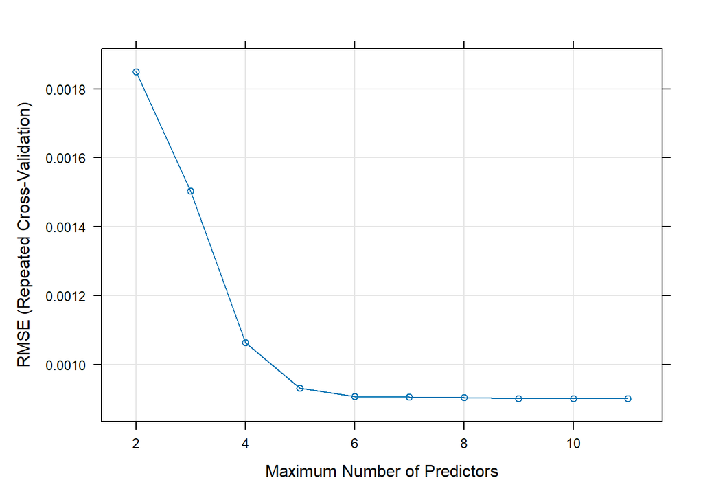

```r
plot(for_tune)
```

```r
coef(for_tune$finalModel, for_tune$bestTune$nvmax)
```

```
##         (Intercept)       fixed.acidity    volatile.acidity         citric.acid
##        9.946966e-01        1.003596e-03        9.456015e-05        1.367094e-04
##      residual.sugar free.sulfur.dioxide             alcohol                  pH
##        1.608989e-03       -6.489241e-05       -1.471179e-03        6.280436e-04
##           sulphates             quality                type
##        2.400715e-04       -7.133889e-05        7.504092e-04
```

```r
test_results$frw <- predict(for_tune, testing)
postResample(pred = test_results$frw,  obs = test_results$density)
```

```
##         RMSE     Rsquared          MAE
## 0.0007463979 0.9334326602 0.0005988287
```

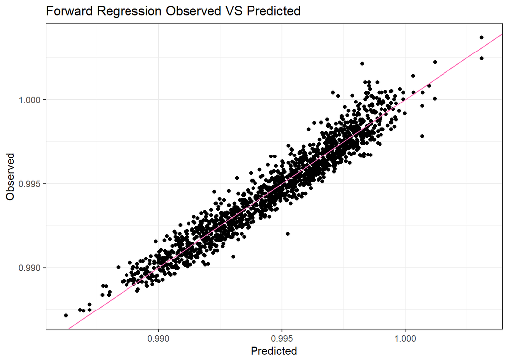

```r
qplot(test_results$frw, test_results$density) +
  labs(title = "Forward Regression Observed VS Predicted", x = "Predicted", y =
         "Observed") +
  geom_abline(intercept = 0,
              slope = 1,
              colour = "hotpink") +
  theme_bw()
```

### Backward regression

```r
model = density ~ fixed.acidity + volatile.acidity + residual.sugar + alcohol + sulphates
back_tune <- train(
  model,
  data = training,
  method = "leapBackward",
  tuneLength = 5,
  preProc = c('scale', 'center'),
  trControl = ctrl
)
back_tune
```

```
## Linear Regression with Backwards Selection
##
## 4874 samples
##    5 predictor
##
## Pre-processing: scaled (5), centered (5)
## Resampling: Cross-Validated (10 fold, repeated 1 times)
## Summary of sample sizes: 4386, 4388, 4386, 4387, 4387, 4386, ...
## Resampling results across tuning parameters:
##
##   nvmax  RMSE         Rsquared   MAE
##   2      0.001852750  0.6281742  0.0014054452
##   3      0.001500785  0.7558612  0.0011238410
##   4      0.001340854  0.8049754  0.0009932655
##   5      0.001224905  0.8366529  0.0008890378
##   6      0.001224905  0.8366529  0.0008890378
##
## RMSE was used to select the optimal model using the smallest value.
## The final value used for the model was nvmax = 5.
```

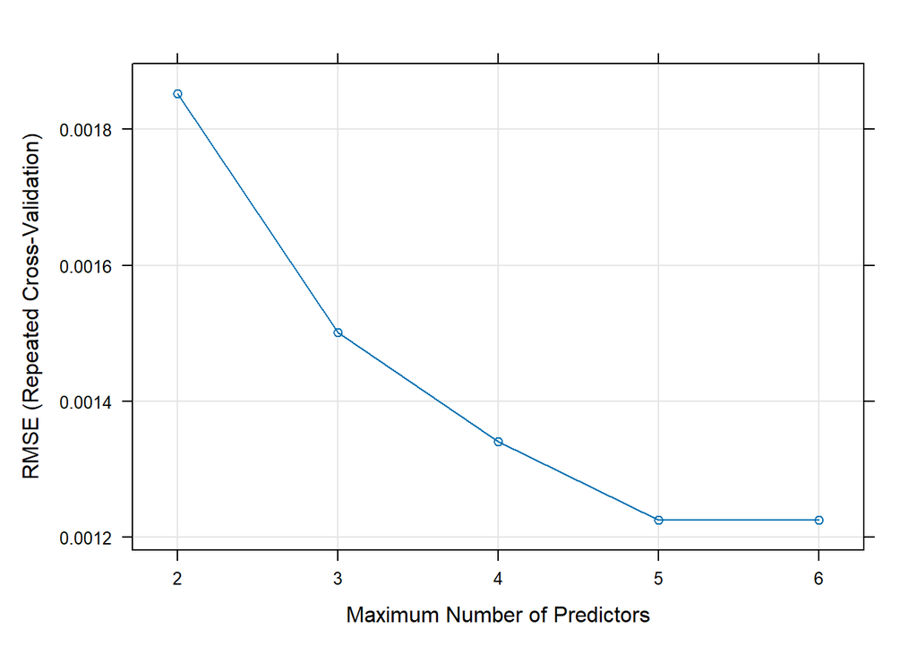

```r
plot(back_tune)
```

```r
coef(back_tune$finalModel, back_tune$bestTune$nvmax)
```

```
##      (Intercept)    fixed.acidity volatile.acidity   residual.sugar
##     0.9946965552     0.0010168677     0.0006213837     0.0013526747
##          alcohol        sulphates
##    -0.0014974090     0.0005798010
```

```r
test_results$bw <- predict(back_tune, testing)
postResample(pred = test_results$bw,  obs = test_results$density)
```

```
##         RMSE     Rsquared          MAE
## 0.0010836861 0.8591561240 0.0008471312
```

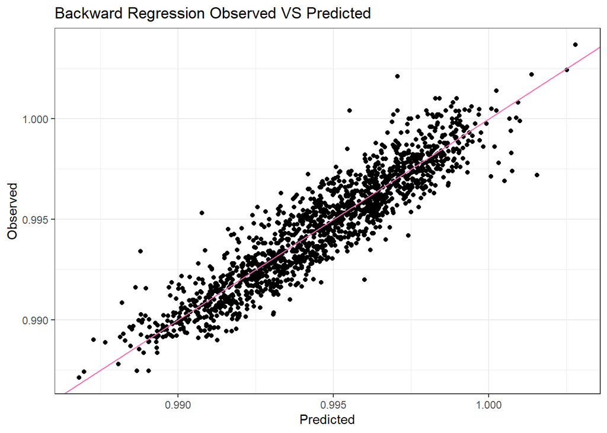

```r
qplot(test_results$bw, test_results$density) +
  labs(title = "Backward Regression Observed VS Predicted", x = "Predicted", y =
         "Observed") +
  geom_abline(intercept = 0,
              slope = 1,
              colour = "hotpink") +
  theme_bw()
```

### Stepwise regression

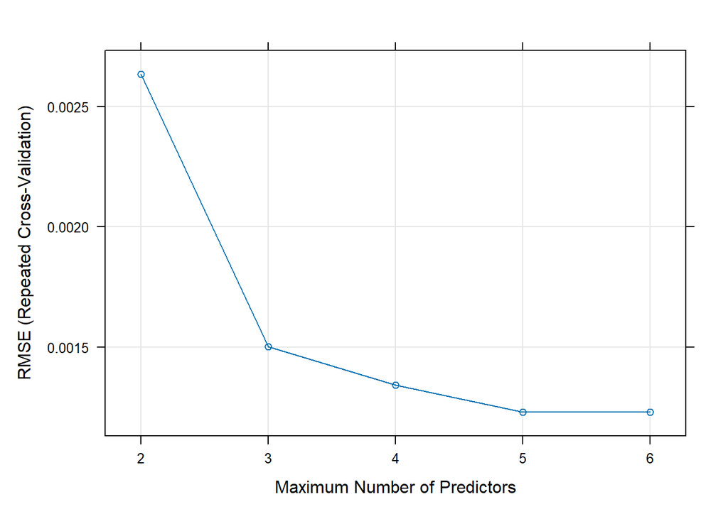

```r
step_tune <- train(
  model,
  data = training,
  method = "leapSeq",
  preProc = c('scale', 'center'),
  tuneLength = 5,
  trControl = ctrl
)
plot(step_tune)
```

```r
coef(step_tune$finalModel, step_tune$bestTune$nvmax)
```

```
##      (Intercept)    fixed.acidity volatile.acidity   residual.sugar
##     0.9946965552     0.0010168677     0.0006213837     0.0013526747
##          alcohol        sulphates
##    -0.0014974090     0.0005798010
```

```r
test_results$seq <- predict(step_tune, testing)
postResample(pred = test_results$seq,  obs = test_results$density)
```

```
##         RMSE     Rsquared          MAE
## 0.0010836861 0.8591561240 0.0008471312
```

To sum up, until this point, there is no clear method that stands out, all of them give very good results.

### Ridge regression

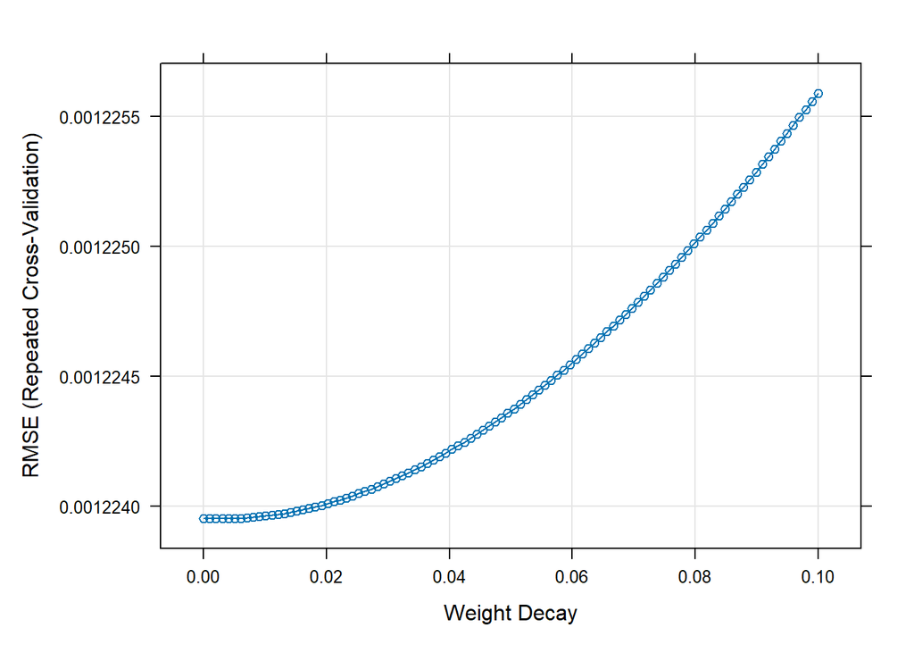

```r
ridge_grid <- expand.grid(lambda = seq(0, .1, length = 100))


ridge_tune <- train(
  model,
  data = training,
  method = 'ridge',
  tuneGrid = ridge_grid,
  preProc = c('scale', 'center'),
  trControl = ctrl
)
plot(ridge_tune)
```

```r
ridge_tune$bestTune
```

```
##        lambda
## 4 0.003030303
```

```r
test_results$ridge <- predict(ridge_tune, testing)

postResample(pred = test_results$ridge,  obs = test_results$density)
```

```
##         RMSE     Rsquared          MAE
## 0.0010836864 0.8591684932 0.0008470589
```

As before, we obtain very good results with a R^2 close to 0.9 and an error very close to 0.

### Lasso

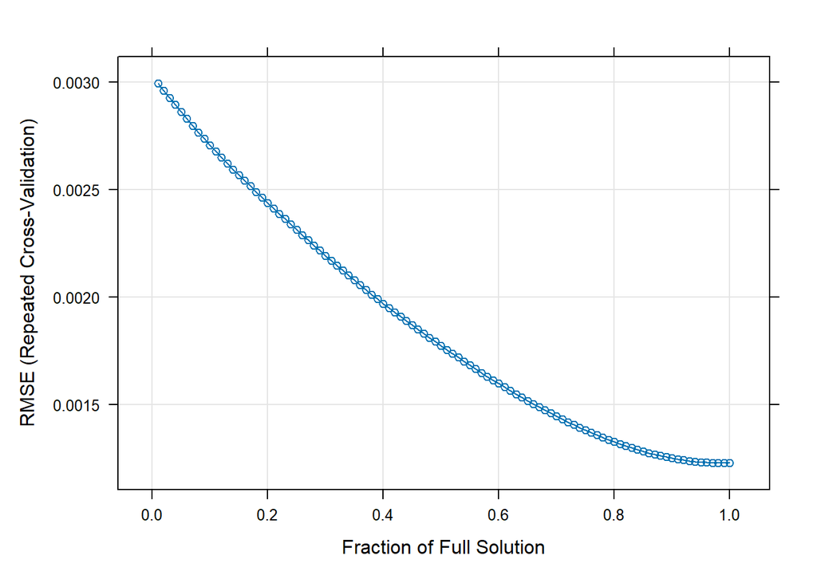

```r
lasso_grid <- expand.grid(fraction = seq(.01, 1, length = 100))

lasso_tune <- train(
  model,
  data = training,
  method = 'lasso',
  preProc = c('scale', 'center'),
  tuneGrid = lasso_grid,
  trControl = ctrl
)
plot(lasso_tune)
```

```r
lasso_tune$bestTune
```

```
##    fraction
## 99     0.99
```

```r
test_results$lasso <- predict(lasso_tune, testing)
postResample(pred = test_results$lasso,  obs = test_results$density)
```

```
##         RMSE     Rsquared          MAE
## 0.0010832755 0.8591819622 0.0008474608
```

### Elastic Net

```r
lambda_seq <- exp(seq(log(0.001), log(0.1), length.out = 100))
elastic_grid <-
  expand.grid(alpha = seq(0, 1, length.out = 10), lambda = lambda_seq)

glmnet_tune <- train(
  model,
  data = training,
  method = 'glmnet',
  preProc = c('scale', 'center'),
  tuneGrid = elastic_grid,
  trControl = ctrl
)
```

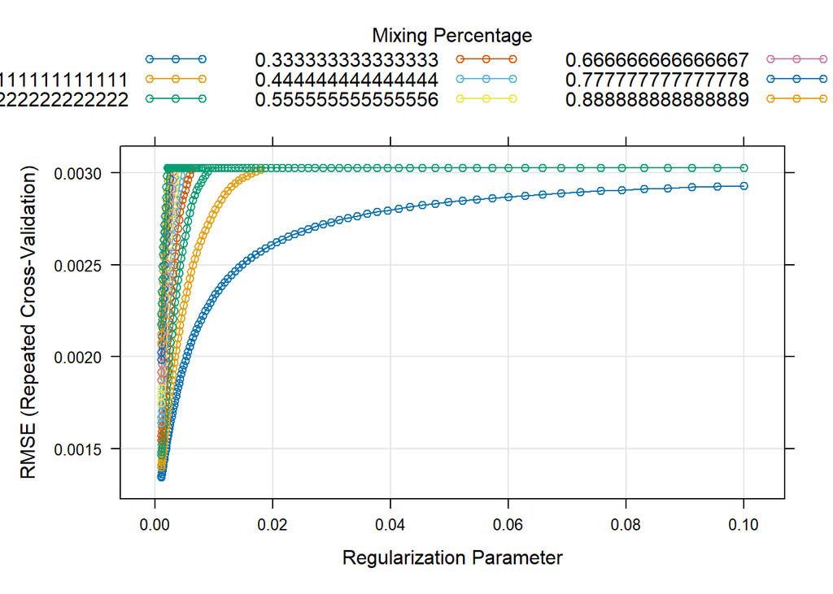

```r
plot(glmnet_tune)
```

```r
print(glmnet_tune$bestTune)
```

```
##   alpha lambda
## 1     0  0.001
```

```r
test_results$glmnet <- predict(glmnet_tune, testing)
performance <-
  postResample(pred = test_results$glmnet, obs = testing$density)


print(performance)
```

```
##         RMSE     Rsquared          MAE
## 0.0011972795 0.8598506180 0.0009659888
```

### Machine Learning tools

#### kNN

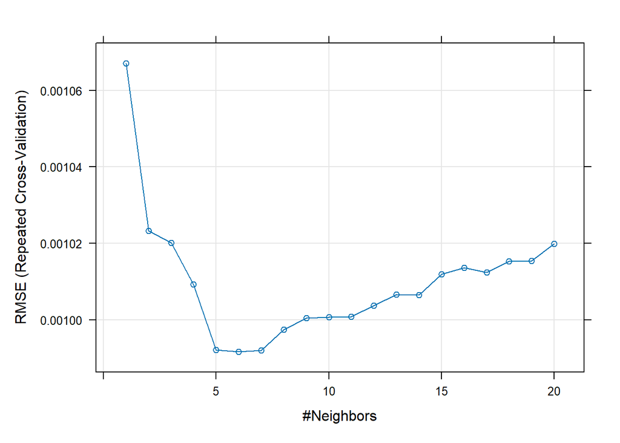

```r
neighbors_grid <- expand.grid(k = seq(1, 20, by = 1))


knn_tune <- train(
  model,
  data = training,
  method = "knn",
  preProc = c('scale', 'center'),
  tuneGrid = neighbors_grid,
  trControl = ctrl
)


plot(knn_tune)
```

```r
test_results$knn <- predict(knn_tune, testing)
performance <-
  postResample(pred = test_results$knn, obs = testing$density)


print(performance)
```

```
##         RMSE     Rsquared          MAE
## 0.0008485391 0.9135829653 0.0006093929
```

#### Random Forests

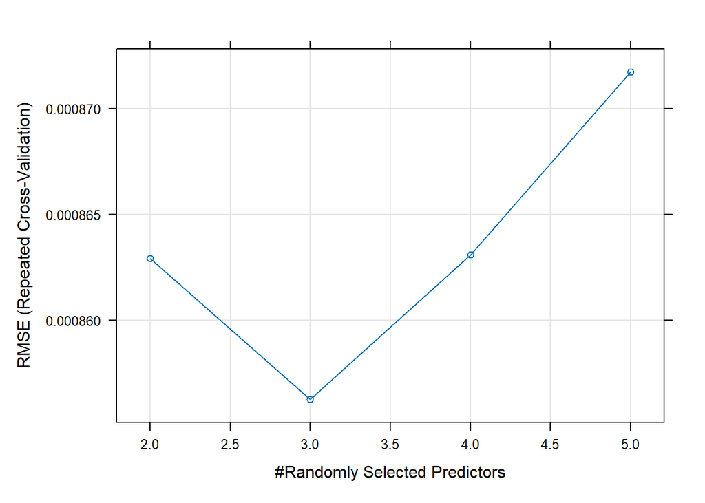

```r
tuneGrid <- expand.grid(mtry = 2:5)

rf_tune <- train(
  model,
  data = training,
  method = "rf",
  preProc = c('scale', 'center'),
  trControl = ctrl,
  ntree = 100,
  tuneGrid = tuneGrid,
  importance = TRUE
)

plot(rf_tune)
```

```r
test_results$rf <- predict(rf_tune, testing)
performance <-
  postResample(pred = test_results$rf, obs = test_results$density)


print(performance)
```

```
##         RMSE     Rsquared          MAE
## 0.0006816434 0.9444676960 0.0004644121
```

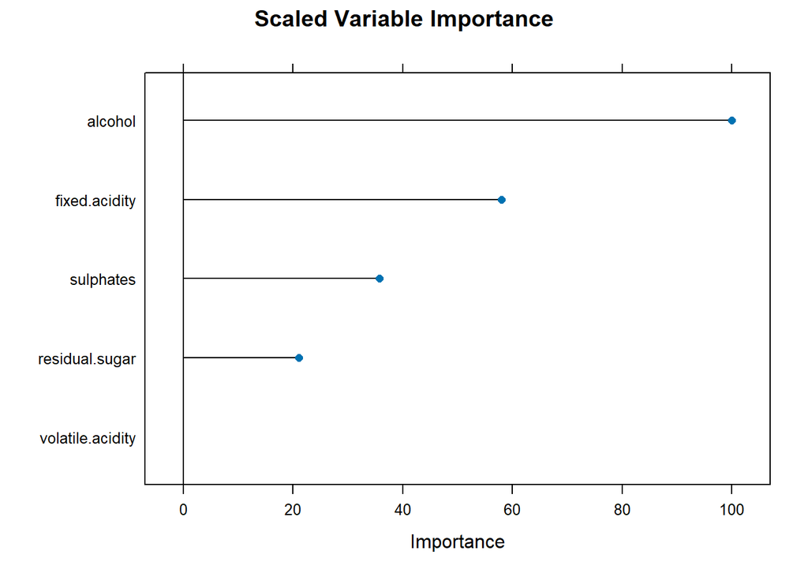

```r
var_imp <- varImp(rf_tune, scale = TRUE)
plot(var_imp, main = "Scaled Variable Importance")
```

From the first graph we get that the model performs better for smaller predictors. Also, the second graph shows that the variable alcohol has the highest important score with a significant difference. Therefore, we can say as previously that the alcohol variable is the most significant one in terms of density.

#### Gradient Boosting

```r
xgb_tune <- train(
  model,
  data = training,
  method = "xgbTree",
  preProc = c('scale', 'center'),
  verbosity = 0,
  trControl = ctrl
)

test_results$xgb <- predict(xgb_tune, testing)

postResample(pred = test_results$xgb,  obs = test_results$density)
```

```
##         RMSE     Rsquared          MAE
## 0.0008032129 0.9226609391 0.0005922199
```

#### Ensemble

```r
apply(test_results, 2, function(x)
  mean(abs(x - test_results$density)))
```

```
##      density           lm          frw           bw          seq        ridge
## 0.0000000000 0.0005988287 0.0005988287 0.0008471312 0.0008471312 0.0008470589
##        lasso       glmnet          knn           rf          xgb
## 0.0008474608 0.0009659888 0.0006093929 0.0004644121 0.0005922199
```

From this, we obtain really small errors which indicates a very good performance of the models

```r
test_results$comb = (test_results$knn + test_results$rf + test_results$xgb) /
  3


resample_result = postResample(pred = test_results$comb,  obs = test_results$density)


print(resample_result)
```

```
##         RMSE     Rsquared          MAE
## 0.0007128122 0.9392697331 0.0005106858
```

### Final predictions

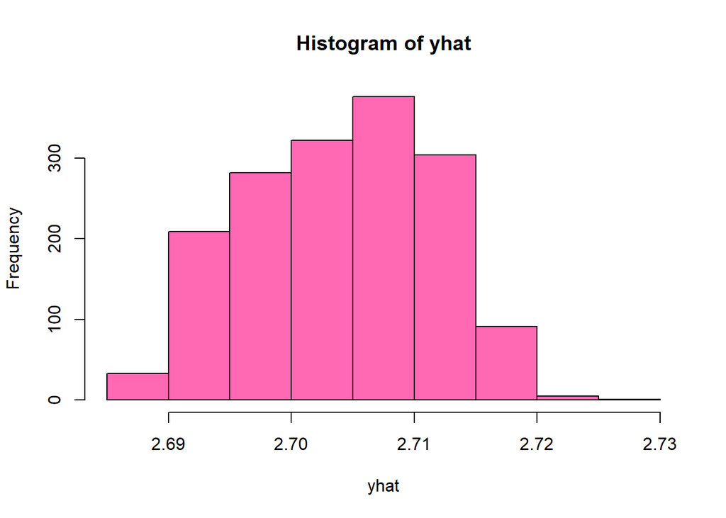

```r
yhat = exp(test_results$comb)

hist(yhat, col = "hotpink")
```

This histogram shows that the combined model tends to predict values within a specific range with a central tendency around 2.71. Also, we can see that the shape of the distribution looks approximately normal, which suggests that the predictions of yhat are centered around a mean value with a symmetric spread on both sides. Final, we can point out that the range of predictions is relatively narrow (from about 2.69 to 2.73), indicating that most predictions are close to each other which means high precision

### Prediction Intervals

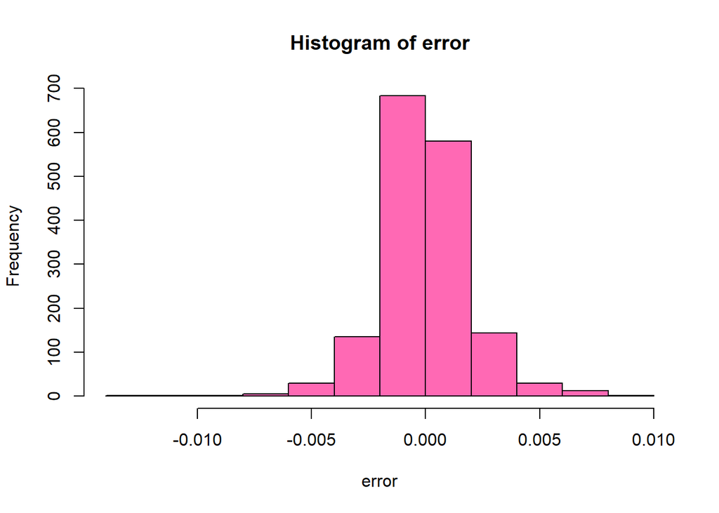

```r
y = exp(test_results$density)
error = y - yhat
hist(error, col = "hotpink")
```

From this graph we see that there is a balance between positive and negative values which means that the model nether overestimates or underestimates the prediction as it is centred around zero. Most of the errors are close to zero, suggesting that the model predictions are generally accurate. We also have narrow spread, that tells us that the model’s predictions are consistently close to the actual values. So, to sum up, this histogram suggests that the model’s predictions are quite accurate, with a small error margin, and that there is no evidence of systematic bias in the predictions.

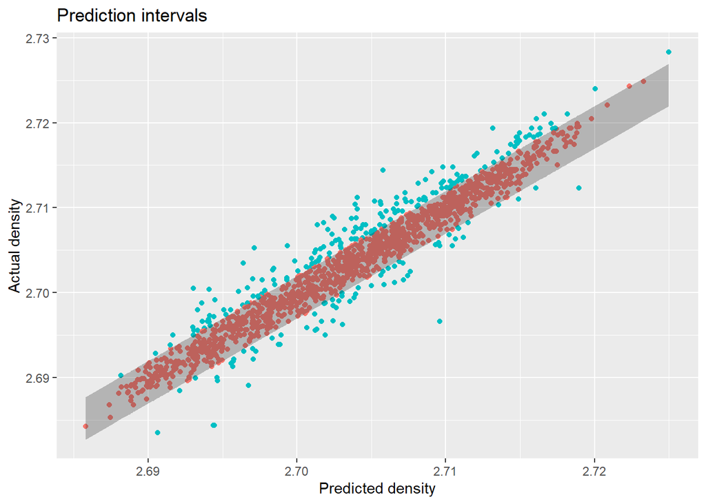

```r
noise = error[1:100]


lwr = yhat[101:length(yhat)] + quantile(noise, 0.05, na.rm = TRUE)
upr = yhat[101:length(yhat)] + quantile(noise, 0.95, na.rm = TRUE)

predictions = data.frame(
  real = y[101:length(y)],
  fit = yhat[101:length(yhat)],
  lwr = lwr,
  upr = upr
)


predictions = predictions %>% mutate(out = factor(if_else(real < lwr |
                                                            real > upr, "Outside", "Inside")))


ggplot(predictions, aes(x = fit, y = real)) +
  geom_point(aes(color = out)) + theme(legend.position = "none") +
  geom_ribbon(aes(ymin = lwr, ymax = upr), alpha = 0.3) +
  labs(title = "Prediction intervals", x = "Predicted density", y = "Actual density")
```

The points seem to be tightly clustered along the line where the actual density equals the predicted density, indicating a good fit. The model also doesn’t seem to have a strong bias. Furthermore, we can see that the noise remains constant across the range of predictions. The shaded area has constant width therefore indicating the same level of confidence in the predictions across different values. So, after all this analysis we can say that the model predicts the actual density quite well, with a high level of confidence that the predictions will fall within a narrow range of the true values.

### Final thoughts

we were paid special attention to how well our models worked. we adjusted some settings and used some advanced methods to make your predictions better, without making our models too complicated or too specific. We checked how accurate our predictions were, by comparing them to the real values. From this we got that the errors are very close to 0, which means our predictions were close.

To make our predictions even better, you combined some of the models by taking the average of their predictions. This allowed us to use the strengths of each model and avoid the weaknesses which made our predictions more reliable.